# F9_01_REV_TOT_CY

Total revenue - current year · Amount report

## Overview

**Description**

Total revenue - CY

**Table**

`F9-P01-T00-SUMMARY` (one)

**Location code**

`F990-PC-PART-01-LINE-12-CY`, `F990-EZ-PART-01-LINE-09`

**Family**

`F990-PC-PART-01-LINE-12-CY`

**Data type**

numeric (xsd: USAmountType)

**Scope**

PZ

**Status**

unreviewed

6

xpaths mapped (4 observed)

5,944,739

filings with a value

2009–2024

tax years observed

2

open flags (0 errors)

## Flags

| Severity | Flag | Xpath | Detail |
| --- | --- | --- | --- |
| ⓘ info | `UNOBSERVED` | IRS990/Form990PartI/TotalRevenueCurrentYear | never observed in TY2009-2024 filings |
| ⓘ info | `UNOBSERVED` | IRS990EZ/TotalRevenueCurrentYear | never observed in TY2009-2024 filings |

## Xpaths

All mapped xpaths (under /Return/ReturnData or /Return/ReturnHeader), oldest first. Charts label each series by its xpath.

| Xpath | Form | First year | Last year | Versions | Filings | Repeats in |
| --- | --- | --- | --- | --- | --- | --- |
| IRS990/TotalRevenueCurrentYear | 990 | 2009 | 2012 | 19 | 495,528 | 0.0% |
| IRS990EZ/TotalRevenue | 990-EZ | 2009 | 2012 | 18 | 251,849 | 0.0% |
| IRS990/CYTotalRevenueAmt | 990 | 2013 | 2024 | 38 | 3,349,613 | 0.0% |
| IRS990EZ/TotalRevenueAmt | 990-EZ | 2013 | 2024 | 38 | 1,847,749 | 0.0% |
| IRS990/Form990PartI/TotalRevenueCurrentYear | 990 |  |  |  | 0 |  |
| IRS990EZ/TotalRevenueCurrentYear | 990-EZ |  |  |  | 0 |  |

## Coverage

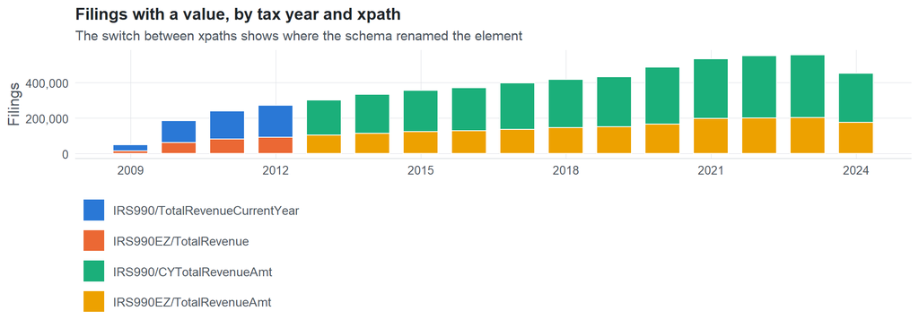

**Table view**

Table view: filings by tax year and series

| Tax year | IRS990/TotalRevenueCurrentYear | IRS990EZ/TotalRevenue | IRS990/CYTotalRevenueAmt | IRS990EZ/TotalRevenueAmt |
| --- | --- | --- | --- | --- |
| 2009 | 33311 | 15,342 | 0 | 0 |
| 2010 | 123025 | 62,440 | 0 | 0 |
| 2011 | 159504 | 81,299 | 0 | 0 |
| 2012 | 179688 | 92,768 | 0 | 0 |
| 2013 | 0 | 0 | 198,855 | 103,155 |
| 2014 | 0 | 0 | 218,619 | 114,936 |
| 2015 | 0 | 0 | 233,519 | 123,183 |
| 2016 | 0 | 0 | 243,903 | 128,553 |
| 2017 | 0 | 0 | 261,612 | 136,990 |
| 2018 | 0 | 0 | 271,442 | 146,854 |
| 2019 | 0 | 0 | 283,694 | 150,035 |
| 2020 | 0 | 0 | 320,343 | 166,238 |
| 2021 | 0 | 0 | 336,488 | 198,397 |
| 2022 | 0 | 0 | 349,062 | 201,773 |
| 2023 | 0 | 0 | 354,774 | 202,244 |
| 2024 | 0 | 0 | 277,302 | 175,391 |

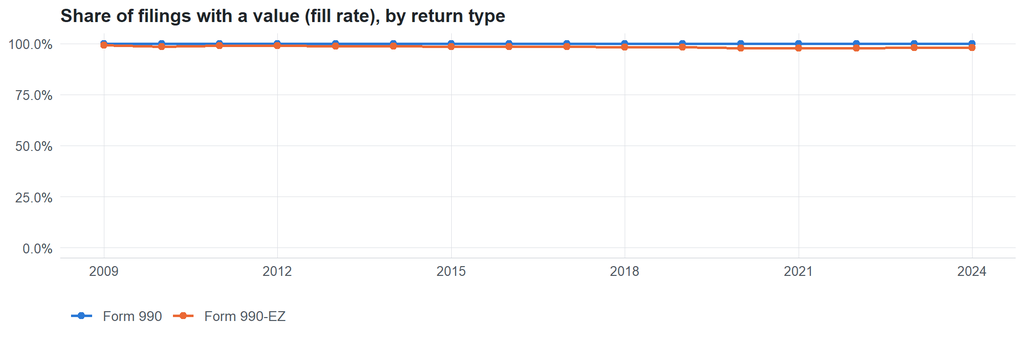

**Table view**

Table view: fill rate

| Tax year | Return type | Filings | All filings | Fill rate |
| --- | --- | --- | --- | --- |
| 2009 | Form 990 | 33,311 | 33,311 | 100.00% |
| 2009 | Form 990-EZ | 15,342 | 15,470 | 99.17% |
| 2010 | Form 990 | 123,025 | 123,025 | 100.00% |
| 2010 | Form 990-EZ | 62,440 | 63,326 | 98.60% |
| 2011 | Form 990 | 159,504 | 159,504 | 100.00% |
| 2011 | Form 990-EZ | 81,299 | 82,048 | 99.09% |
| 2012 | Form 990 | 179,688 | 179,688 | 100.00% |
| 2012 | Form 990-EZ | 92,768 | 93,750 | 98.95% |
| 2013 | Form 990 | 198,855 | 198,855 | 100.00% |
| 2013 | Form 990-EZ | 103,155 | 104,375 | 98.83% |
| 2014 | Form 990 | 218,619 | 218,619 | 100.00% |
| 2014 | Form 990-EZ | 114,936 | 116,417 | 98.73% |
| 2015 | Form 990 | 233,519 | 233,519 | 100.00% |
| 2015 | Form 990-EZ | 123,183 | 124,894 | 98.63% |
| 2016 | Form 990 | 243,903 | 243,903 | 100.00% |
| 2016 | Form 990-EZ | 128,553 | 130,484 | 98.52% |
| 2017 | Form 990 | 261,612 | 261,612 | 100.00% |
| 2017 | Form 990-EZ | 136,989 | 139,144 | 98.45% |
| 2018 | Form 990 | 271,442 | 271,442 | 100.00% |
| 2018 | Form 990-EZ | 146,854 | 149,384 | 98.31% |
| 2019 | Form 990 | 283,694 | 283,694 | 100.00% |
| 2019 | Form 990-EZ | 150,034 | 152,622 | 98.30% |
| 2020 | Form 990 | 320,342 | 320,342 | 100.00% |
| 2020 | Form 990-EZ | 166,237 | 169,864 | 97.86% |
| 2021 | Form 990 | 336,480 | 336,480 | 100.00% |
| 2021 | Form 990-EZ | 198,392 | 202,724 | 97.86% |
| 2022 | Form 990 | 349,055 | 349,055 | 100.00% |
| 2022 | Form 990-EZ | 201,768 | 206,130 | 97.88% |
| 2023 | Form 990 | 354,768 | 354,768 | 100.00% |
| 2023 | Form 990-EZ | 202,241 | 206,379 | 97.99% |
| 2024 | Form 990 | 277,298 | 277,298 | 100.00% |
| 2024 | Form 990-EZ | 175,390 | 178,867 | 98.06% |

## Values

| Result | Check | Detail |
| --- | --- | --- |
| ✓ pass | Values parse as numbers | 100.0% of values are numeric |
| ✓ pass | No sudden change in the median between adjacent years | largest change 2.9x (IRS990/TotalRevenueCurrentYear, 990, TY2010) |
| ✓ pass | Pooled xpaths are on the same scale (same return type) | largest ratio of medians between xpaths: 1.4x |
| ⓘ info | Sign convention | 0.44% of values are negative (fine for net amounts, suspicious for gross amounts) |

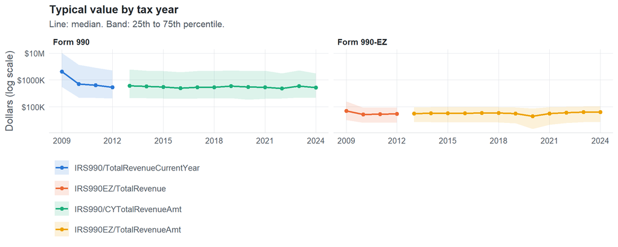

**Table view**

Table view: quartiles by tax year

| Series | Return | Tax year | Filings | P25 | Median | P75 |
| --- | --- | --- | --- | --- | --- | --- |
| IRS990/TotalRevenueCurrentYear | 990 | 2009 | 33,311 | 555,672 | 2,040,476 | 10,073,395 |
| IRS990/TotalRevenueCurrentYear | 990 | 2010 | 123,025 | 219,193 | 703,547 | 3,674,877 |
| IRS990/TotalRevenueCurrentYear | 990 | 2011 | 159,504 | 216,304 | 644,834 | 2,860,142 |
| IRS990/TotalRevenueCurrentYear | 990 | 2012 | 179,688 | 204,127 | 543,767 | 2,276,808 |
| IRS990EZ/TotalRevenue | 990EZ | 2009 | 15,342 | 32,544 | 71,370 | 160,614 |
| IRS990EZ/TotalRevenue | 990EZ | 2010 | 62,440 | 25,716 | 52,216 | 92,554 |
| IRS990EZ/TotalRevenue | 990EZ | 2011 | 81,299 | 25,660 | 53,581 | 93,266 |
| IRS990EZ/TotalRevenue | 990EZ | 2012 | 92,768 | 26,323 | 55,185 | 94,827 |
| IRS990/CYTotalRevenueAmt | 990 | 2013 | 198,855 | 215,085 | 614,680 | 2,467,630 |
| IRS990/CYTotalRevenueAmt | 990 | 2014 | 218,619 | 210,201 | 573,964 | 2,248,462 |
| IRS990/CYTotalRevenueAmt | 990 | 2015 | 233,519 | 206,425 | 557,686 | 2,168,353 |
| IRS990/CYTotalRevenueAmt | 990 | 2016 | 243,903 | 199,509 | 503,490 | 1,963,978 |
| IRS990/CYTotalRevenueAmt | 990 | 2017 | 261,612 | 205,308 | 542,240 | 2,150,137 |
| IRS990/CYTotalRevenueAmt | 990 | 2018 | 271,442 | 204,491 | 534,299 | 2,144,704 |
| IRS990/CYTotalRevenueAmt | 990 | 2019 | 283,694 | 209,941 | 588,383 | 2,254,709 |
| IRS990/CYTotalRevenueAmt | 990 | 2020 | 320,342 | 184,783 | 554,011 | 2,188,572 |
| IRS990/CYTotalRevenueAmt | 990 | 2021 | 336,480 | 202,111 | 534,675 | 2,207,788 |
| IRS990/CYTotalRevenueAmt | 990 | 2022 | 349,055 | 203,011 | 485,449 | 1,784,909 |
| IRS990/CYTotalRevenueAmt | 990 | 2023 | 354,768 | 220,434 | 587,093 | 2,257,245 |
| IRS990/CYTotalRevenueAmt | 990 | 2024 | 277,298 | 215,892 | 529,173 | 1,759,353 |
| IRS990EZ/TotalRevenueAmt | 990EZ | 2013 | 103,155 | 27,005 | 56,665 | 95,641 |
| IRS990EZ/TotalRevenueAmt | 990EZ | 2014 | 114,936 | 27,000 | 57,344 | 97,043 |
| IRS990EZ/TotalRevenueAmt | 990EZ | 2015 | 123,183 | 26,577 | 57,581 | 97,247 |
| IRS990EZ/TotalRevenueAmt | 990EZ | 2016 | 128,553 | 26,296 | 57,845 | 97,561 |
| IRS990EZ/TotalRevenueAmt | 990EZ | 2017 | 136,989 | 27,007 | 58,527 | 98,374 |
| IRS990EZ/TotalRevenueAmt | 990EZ | 2018 | 146,854 | 26,471 | 58,830 | 98,582 |
| IRS990EZ/TotalRevenueAmt | 990EZ | 2019 | 150,034 | 24,298 | 56,779 | 96,339 |
| IRS990EZ/TotalRevenueAmt | 990EZ | 2020 | 166,237 | 14,885 | 45,252 | 86,385 |
| IRS990EZ/TotalRevenueAmt | 990EZ | 2021 | 198,392 | 21,569 | 56,740 | 97,461 |
| IRS990EZ/TotalRevenueAmt | 990EZ | 2022 | 201,768 | 24,840 | 61,059 | 101,473 |
| IRS990EZ/TotalRevenueAmt | 990EZ | 2023 | 202,241 | 26,847 | 63,130 | 103,485 |
| IRS990EZ/TotalRevenueAmt | 990EZ | 2024 | 175,390 | 27,775 | 64,039 | 104,375 |

Summary by xpath and return type (all years)

| Series | Return | Filings | % numeric | % zero | % negative | Median (typical year) | P99 (typical year) |
| --- | --- | --- | --- | --- | --- | --- | --- |
| IRS990/TotalRevenueCurrentYear | 990 | 495,528 | 100 | 0.5 | 0.5 | 617345 | 201949847 |
| IRS990EZ/TotalRevenue | 990EZ | 251,849 | 100 | 1.5 | 0.4 | 57547 | 193829 |
| IRS990/CYTotalRevenueAmt |  | 26 |  |  |  |  |  |
| IRS990/CYTotalRevenueAmt | 990 | 3,349,587 | 100 | 0.9 | 0.4 | 451857 | 131799719 |
| IRS990EZ/TotalRevenueAmt |  | 17 |  |  |  |  |  |
| IRS990EZ/TotalRevenueAmt | 990EZ | 1,847,732 | 100 | 2.7 | 0.4 | 57806 | 191740 |

## Examples

| Tax year | Return | Xpath | Organization | Value | Source |
| --- | --- | --- | --- | --- | --- |
| 2024 | 990 | IRS990/CYTotalRevenueAmt | CHRISTIAN SHANE FONVILLE YOUTH | 44977 | [XML](https://gt990datalake-rawdata.s3.amazonaws.com/EfileData/XmlFiles/202511059349301411_public.xml) |
| 2024 | 990EZ | IRS990EZ/TotalRevenueAmt | SAINT CLAIR HOUSE INC | 115995 | [XML](https://gt990datalake-rawdata.s3.amazonaws.com/EfileData/XmlFiles/202521329349201597_public.xml) |
| 2023 | 990 | IRS990/CYTotalRevenueAmt | COMMUNITY AMBULANCE SERVICE | 5395271 | [XML](https://gt990datalake-rawdata.s3.amazonaws.com/EfileData/XmlFiles/202540169349300304_public.xml) |
| 2023 | 990EZ | IRS990EZ/TotalRevenueAmt | GALBRAITH GRAVITY JUNIOR RACING | 68343 | [XML](https://gt990datalake-rawdata.s3.amazonaws.com/EfileData/XmlFiles/202422849349200002_public.xml) |
| 2022 | 990 | IRS990/CYTotalRevenueAmt | FRANK TOWN OPEN HEARTS MINISTRY INC | 1436378 | [XML](https://gt990datalake-rawdata.s3.amazonaws.com/EfileData/XmlFiles/202303189349302170_public.xml) |
| 2022 | 990EZ | IRS990EZ/TotalRevenueAmt | BEHIND CLOSED DOORS MINISTRIES | 4479 | [XML](https://gt990datalake-rawdata.s3.amazonaws.com/EfileData/XmlFiles/202311239349202216_public.xml) |
| 2021 | 990 | IRS990/CYTotalRevenueAmt | COULEE REGION HUMANE SOCIETY INC | 2069154 | [XML](https://gt990datalake-rawdata.s3.amazonaws.com/EfileData/XmlFiles/202243119349301379_public.xml) |
| 2021 | 990EZ | IRS990EZ/TotalRevenueAmt | CHRISTIAN CHURCHES TOGETHER IN THE USA INC | 94436 | [XML](https://gt990datalake-rawdata.s3.amazonaws.com/EfileData/XmlFiles/202201369349206320_public.xml) |
| 2020 | 990 | IRS990/CYTotalRevenueAmt | SOCIAL JUSTICE PUBLIC CHARTER SCHOOL | 1988348 | [XML](https://gt990datalake-rawdata.s3.amazonaws.com/EfileData/XmlFiles/202201309349304660_public.xml) |
| 2020 | 990EZ | IRS990EZ/TotalRevenueAmt | GENESEE TOWNSHIP VETERANS MEMORIAL | 1940 | [XML](https://gt990datalake-rawdata.s3.amazonaws.com/EfileData/XmlFiles/202142879349200014_public.xml) |
| 2019 | 990 | IRS990/CYTotalRevenueAmt | Chauffeurs Teamsters & Helpers Local 878 | 1444372 | [XML](https://gt990datalake-rawdata.s3.amazonaws.com/EfileData/XmlFiles/202043219349315409_public.xml) |
| 2019 | 990EZ | IRS990EZ/TotalRevenueAmt | LIONS INTERNATIONAL ROSELLE | 8114 | [XML](https://gt990datalake-rawdata.s3.amazonaws.com/EfileData/XmlFiles/202023219349200802_public.xml) |

## Reviewer checklist

- The definition matches the form line and instructions for every xpath’s schema years.
- Every xpath pooled here measures the same thing on the 990 and 990-EZ (close enough for analysis).
- The coverage chart has no unexplained gaps or jumps between tax years.
- Each open flag is fixed, or accepted with a note in validation_log.csv.
- Values are whole dollars, not thousands, and not a percentage.
- Current year / prior year and beginning / end of year match the variable name (CY, PY, BOY, EOY).
- Negative values are expected only for net amounts (gains, net income, fund balances).
- The 990 and 990-EZ medians differ only as much as the filer populations do.

Record the review as a row in `inst/extdata/src/validation_log.csv` (variable_name, reviewer, date, status, note). Evidence built 2026-09-23 17:09:04 MST from the ef2 DuckDB builds, TY2009–2024.